# A3: SPL Library Checkouts

Gulnoor Brar

### Introduction

The only books I have ever read in my life have been mystery books or novels. I still to this day love and adore every single Sherlock holmes, novel, movie, show etc, same goes with Hercule Poirot in agatha Cristie’s novels. I kind of miss these types of characters because both of their writers have long gone. So for my love of mystery, I chose this dataset.

### The Dataset

This data was collected and published by Seattle Public Library. 12 different parameters, these included usage class, checkout type, material type, checkout year, checkout month, title, number of checkouts, subject(s), ISBN, creator, publish year, and publication year. I assume it was recorded on a daily-monthly basis since we have many dates throughout the data, this includes months and years. This was collected to display the highest checked-out items monthly. I believe after the Obama administration’s open data initiative, this data has been collected for that exact reason, to provide the public with data the government has. People did not know that their data was being collected, but there is no identifying information so I do not feel it’s unethical, if people were told about the data being collected, people would not choose some books, which would interfere with the data. These people would not take the books which had promiscuous titles or content, which would take away from any projects we are doing now. In many of the data entries Subjects, and Creator was not properly filled out, and left blank for 50K plus books, which makes this data much less reliable. There is not a rating system in public libraries that could tell us if people actually liked the book they took, so while we add the numbers of checkouts, many of them simply could be chalked up to a good title, or cover, but a rather unrewarding experience. So we cannot conclude a best or worst based on these.

### Best Medium?

While it is difficult to say what people like the most we can definately see that audiobooks and ebooks are popular now, I wanted to know what people preferred when they thought of getting a mystery book, and how this has changed over time.

This chart goes over the top 5 mediums and as I thought, audiobooks and ebooks are getting more and more popular by the year

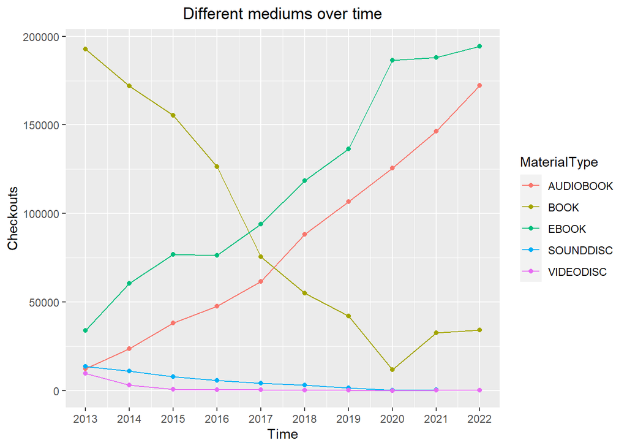

This chart goes over the top 5 mediums and as I thought, audiobooks and ebooks are getting more and more popular by the year.

### Sherlock Holmes vs Hercule Poirot

These were 2 fictional characters, which originated from books, who were both detectives, so obviously I would love to put them up against eachother over the last decade to see who is the best or atlease the more entertaining detective.

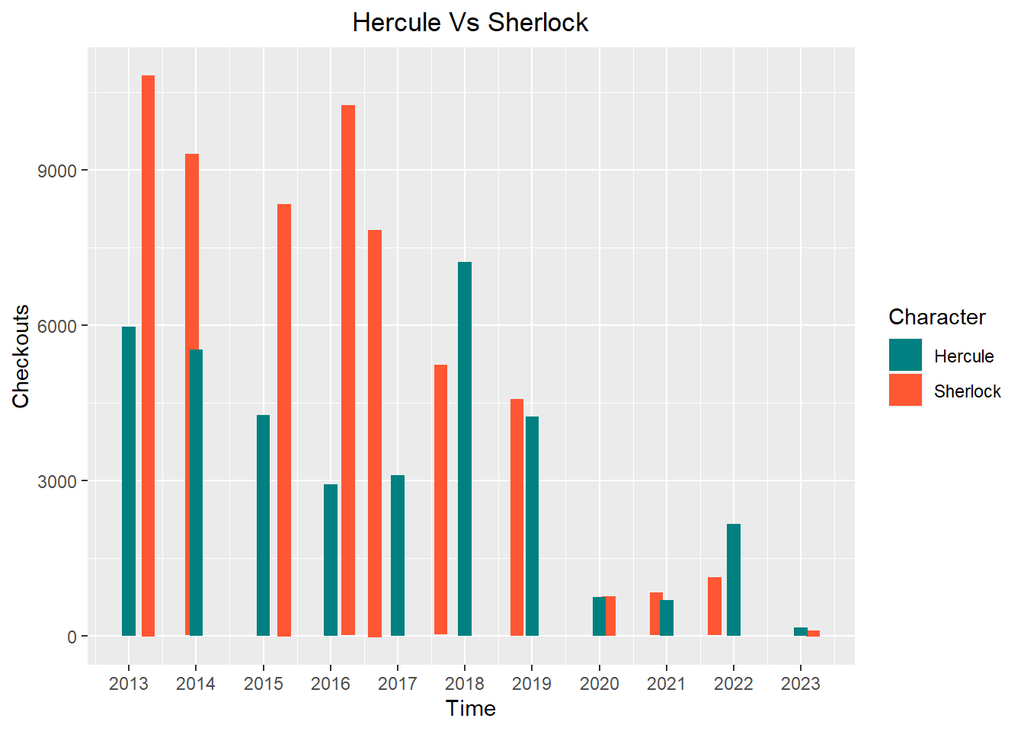

### TOP 5 Authors

The most important aspect of a mystery book/novel is the story, the way its told, the characters and all this is decided by the authors of those books/novels. This is a heatmap chart of the most Checkedout Creators in the last 10 years.

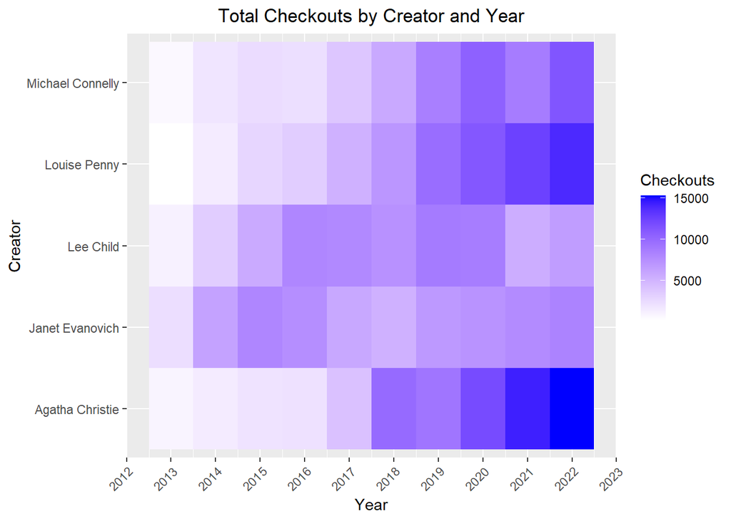

There is almost a clear bias in recent years, this is because alot more people are getting into libraries since they have become easy access and the rise of audio books.

All in all I found this data interesting and I hope you did too.

thank you for reading.